# Projekt z analizy danych - analiza długości śledzia oceanicznego wyławianego w Europie.

Tomasz Sienkiewicz, Jakub Zdanowski

15 November, 2019

# Wprowadzenie

### Opis problemu

Celem projektu jest określenie głównych przyczyn stopniowego zmniejszania się długości śledzi oceanicznych wyławionych w Europie.

### Opis danych

Zbiór danych do analizy składa się z pomiarów śledzi i warunków w jakich żyją z ostatnich 60 lat. Dane były pobierane z połowów komercyjnych jednostek. W ramach połowu jednej jednostki losowo wybierano od 50 do 100 sztuk trzyletnich śledzi.

### Opis zmiennych:

Wszystkie dane, są danymi liczbowymi, nie występują żadne dane kategoryczne.

- **length**: długość złowionego śledzia [cm];
- **cfin1**: dostępność planktonu [zagęszczenie Calanus finmarchicus gat. 1];
- **cfin2**: dostępność planktonu [zagęszczenie Calanus finmarchicus gat. 2];
- **chel1**: dostępność planktonu [zagęszczenie Calanus helgolandicus gat. 1];
- **chel2**: dostępność planktonu [zagęszczenie Calanus helgolandicus gat. 2];
- **lcop1**: dostępność planktonu [zagęszczenie widłonogów gat. 1];
- **lcop2**: dostępność planktonu [zagęszczenie widłonogów gat. 2];
- **fbar**: natężenie połowów w regionie [ułamek pozostawionego narybku];
- **recr**: roczny narybek [liczba śledzi];
- **cumf**: łączne roczne natężenie połowów w regionie [ułamek pozostawionego narybku];
- **totaln**: łączna liczba ryb złowionych w ramach połowu [liczba śledzi] - liczba całkowita;
- **sst**: temperatura przy powierzchni wody [°C];
- **sal**: poziom zasolenia wody [Knudsen ppt];
- **xmonth**: miesiąc połowu [numer miesiąca];
- **nao**: oscylacja północnoatlantycka [mb].

### Inicjalizacja środowiska

```r
library(dplyr)
```

```r
library(ggplot2)
library(GGally) # ggpairplot
library(DT)
library(mice) # for missing data
library(VIM)
library(ggpubr)
prettyTable <- function(table_df, round_columns=numeric(), round_digits=2) {
    DT::datatable(table_df, style="bootstrap", filter = "top", rownames = FALSE, extensions = "Buttons", options = list(dom = 'Bfrtip', buttons = c('copy', 'csv', 'excel', 'pdf', 'print'))) %>%
    formatRound(round_columns, round_digits)
}
```

```r
# Multiple plot function
#
# ggplot objects can be passed in ..., or to plotlist (as a list of ggplot objects)
# - cols:   Number of columns in layout
# - layout: A matrix specifying the layout. If present, 'cols' is ignored.
#
# If the layout is something like matrix(c(1,2,3,3), nrow=2, byrow=TRUE),
# then plot 1 will go in the upper left, 2 will go in the upper right, and
# 3 will go all the way across the bottom.
#
multiplot <- function(..., plotlist=NULL, file, cols=1, layout=NULL) {
  library(grid)

  # Make a list from the ... arguments and plotlist
  plots <- c(list(...), plotlist)

  numPlots = length(plots)

  # If layout is NULL, then use 'cols' to determine layout
  if (is.null(layout)) {
    # Make the panel
    # ncol: Number of columns of plots
    # nrow: Number of rows needed, calculated from # of cols
    layout <- matrix(seq(1, cols * ceiling(numPlots/cols)),
                    ncol = cols, nrow = ceiling(numPlots/cols))
  }

 if (numPlots==1) {
    print(plots[[1]])

  } else {
    # Set up the page
    grid.newpage()
    pushViewport(viewport(layout = grid.layout(nrow(layout), ncol(layout))))

    # Make each plot, in the correct location
    for (i in 1:numPlots) {
      # Get the i,j matrix positions of the regions that contain this subplot
      matchidx <- as.data.frame(which(layout == i, arr.ind = TRUE))

      print(plots[[i]], vp = viewport(layout.pos.row = matchidx$row,
                                      layout.pos.col = matchidx$col))
    }
  }
}
```

# Analiza

### Wczytanie danych i wstepnę oczyszczanie

Pierwszym krokiem jest wczytanie danych oraz bliższe przyjżenie się im. Ponieważ w pliku csv brakujące rekordy zapisane są jako “?” trzeba je poprawnie wczytać.Brakujące dane występują w kolumnach cfin1, cfin2, chel1, chel2, lcop1, lcop2 i lsst. Jako że kolumna x to po prostu numer pomiaru, nie będzie nam potrzebna.

```r
set.seed(23)
data <- read.csv("sledzie.csv", na.strings = c("?"))
lapply(data, function(x) any(is.na(x)))
```

```
## $X
## [1] FALSE
##
## $length
## [1] FALSE
##
## $cfin1
## [1] TRUE
##
## $cfin2
## [1] TRUE
##
## $chel1
## [1] TRUE
##
## $chel2
## [1] TRUE
##
## $lcop1
## [1] TRUE
##
## $lcop2
## [1] TRUE
##
## $fbar
## [1] FALSE
##
## $recr
## [1] FALSE
##
## $cumf
## [1] FALSE
##
## $totaln
## [1] FALSE
##
## $sst
## [1] TRUE
##
## $sal
## [1] FALSE
##
## $xmonth
## [1] FALSE
##
## $nao
## [1] FALSE
```

```r
data <- subset(data, select = -c(X))

summary(data)
```

```
##      length         cfin1             cfin2             chel1
##  Min.   :19.0   Min.   : 0.0000   Min.   : 0.0000   Min.   : 0.000
##  1st Qu.:24.0   1st Qu.: 0.0000   1st Qu.: 0.2778   1st Qu.: 2.469
##  Median :25.5   Median : 0.1111   Median : 0.7012   Median : 5.750
##  Mean   :25.3   Mean   : 0.4458   Mean   : 2.0248   Mean   :10.006
##  3rd Qu.:26.5   3rd Qu.: 0.3333   3rd Qu.: 1.7936   3rd Qu.:11.500
##  Max.   :32.5   Max.   :37.6667   Max.   :19.3958   Max.   :75.000
##                 NA's   :1581      NA's   :1536      NA's   :1555
##      chel2            lcop1              lcop2             fbar
##  Min.   : 5.238   Min.   :  0.3074   Min.   : 7.849   Min.   :0.0680
##  1st Qu.:13.427   1st Qu.:  2.5479   1st Qu.:17.808   1st Qu.:0.2270
##  Median :21.673   Median :  7.0000   Median :24.859   Median :0.3320
##  Mean   :21.221   Mean   : 12.8108   Mean   :28.419   Mean   :0.3304
##  3rd Qu.:27.193   3rd Qu.: 21.2315   3rd Qu.:37.232   3rd Qu.:0.4560
##  Max.   :57.706   Max.   :115.5833   Max.   :68.736   Max.   :0.8490
##  NA's   :1556     NA's   :1653       NA's   :1591
##       recr              cumf             totaln             sst
##  Min.   : 140515   Min.   :0.06833   Min.   : 144137   Min.   :12.77
##  1st Qu.: 360061   1st Qu.:0.14809   1st Qu.: 306068   1st Qu.:13.60
##  Median : 421391   Median :0.23191   Median : 539558   Median :13.86
##  Mean   : 520367   Mean   :0.22981   Mean   : 514973   Mean   :13.87
##  3rd Qu.: 724151   3rd Qu.:0.29803   3rd Qu.: 730351   3rd Qu.:14.16
##  Max.   :1565890   Max.   :0.39801   Max.   :1015595   Max.   :14.73
##                                                        NA's   :1584
##       sal            xmonth            nao
##  Min.   :35.40   Min.   : 1.000   Min.   :-4.89000
##  1st Qu.:35.51   1st Qu.: 5.000   1st Qu.:-1.89000
##  Median :35.51   Median : 8.000   Median : 0.20000
##  Mean   :35.51   Mean   : 7.258   Mean   :-0.09236
##  3rd Qu.:35.52   3rd Qu.: 9.000   3rd Qu.: 1.63000
##  Max.   :35.61   Max.   :12.000   Max.   : 5.08000
##
```

```r
paste0("Ilość badanych przypadków: ", nrow(data), ", ilość zmiennych: ", ncol(data))
```

```
## [1] "Ilosc badanych przypadków: 52582, ilosc zmiennych: 15"
```

```r
head(data, 10)
```

```
##    length   cfin1   cfin2   chel1    chel2   lcop1    lcop2  fbar   recr
## 1    23.0 0.02778 0.27785 2.46875       NA 2.54787 26.35881 0.356 482831
## 2    22.5 0.02778 0.27785 2.46875 21.43548 2.54787 26.35881 0.356 482831
## 3    25.0 0.02778 0.27785 2.46875 21.43548 2.54787 26.35881 0.356 482831
## 4    25.5 0.02778 0.27785 2.46875 21.43548 2.54787 26.35881 0.356 482831
## 5    24.0 0.02778 0.27785 2.46875 21.43548 2.54787 26.35881 0.356 482831
## 6    22.0 0.02778 0.27785 2.46875 21.43548 2.54787       NA 0.356 482831
## 7    24.0 0.02778 0.27785 2.46875 21.43548 2.54787 26.35881 0.356 482831
## 8    23.5 0.02778 0.27785 2.46875 21.43548 2.54787 26.35881 0.356 482831
## 9    22.5 0.02778 0.27785 2.46875 21.43548 2.54787 26.35881 0.356 482831
## 10   22.5 0.02778 0.27785 2.46875 21.43548 2.54787 26.35881 0.356 482831
##         cumf   totaln      sst      sal xmonth nao
## 1  0.3059879 267380.8 14.30693 35.51234      7 2.8
## 2  0.3059879 267380.8 14.30693 35.51234      7 2.8
## 3  0.3059879 267380.8 14.30693 35.51234      7 2.8
## 4  0.3059879 267380.8 14.30693 35.51234      7 2.8
## 5  0.3059879 267380.8 14.30693 35.51234      7 2.8
## 6  0.3059879 267380.8 14.30693 35.51234      7 2.8
## 7  0.3059879 267380.8 14.30693 35.51234      7 2.8
## 8  0.3059879 267380.8 14.30693 35.51234      7 2.8
## 9  0.3059879 267380.8 14.30693 35.51234      7 2.8
## 10 0.3059879 267380.8 14.30693 35.51234      7 2.8
```

W celu poradzenia sobie z brakującymi danymi zostaje wykorzystana metoda MICE (Multivariate Imputation via Chained Equations).

```
## $`1`
```

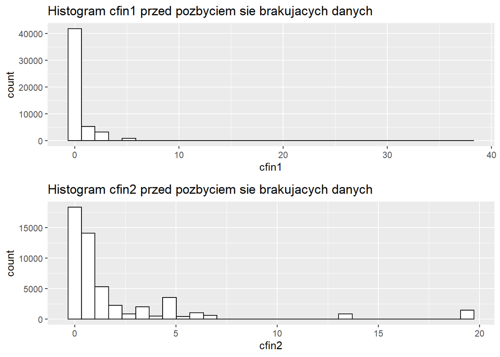

```
##
## $`2`
```

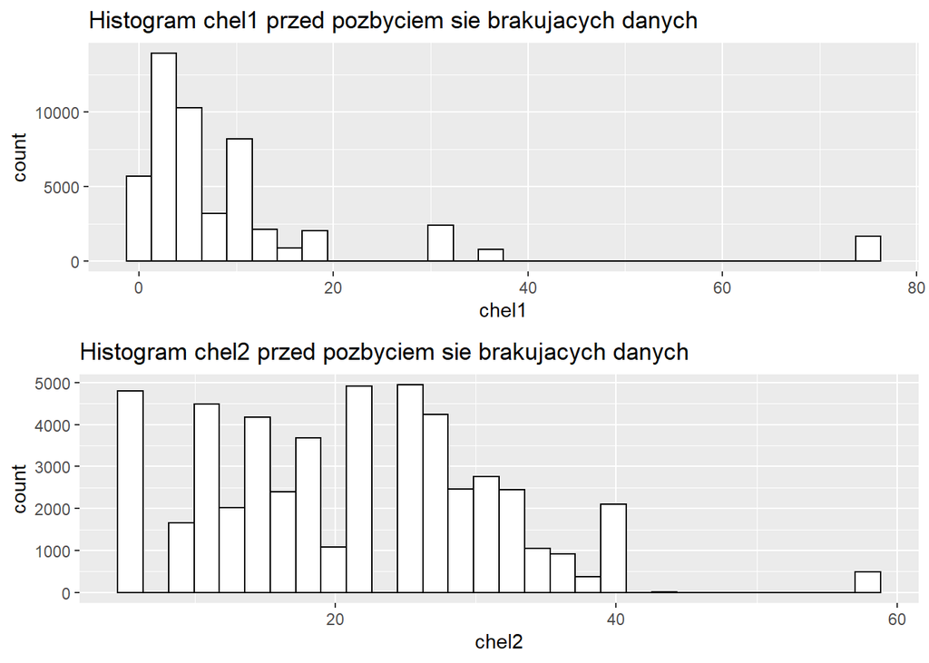

```
##
## $`3`
```

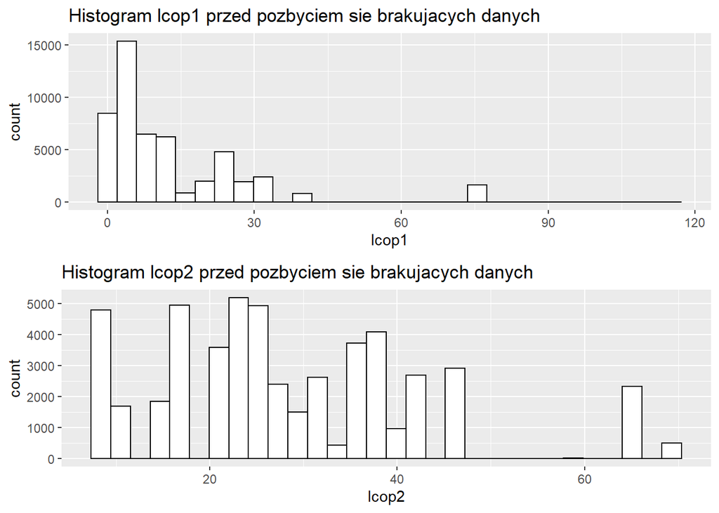

```
##
## $`4`
```

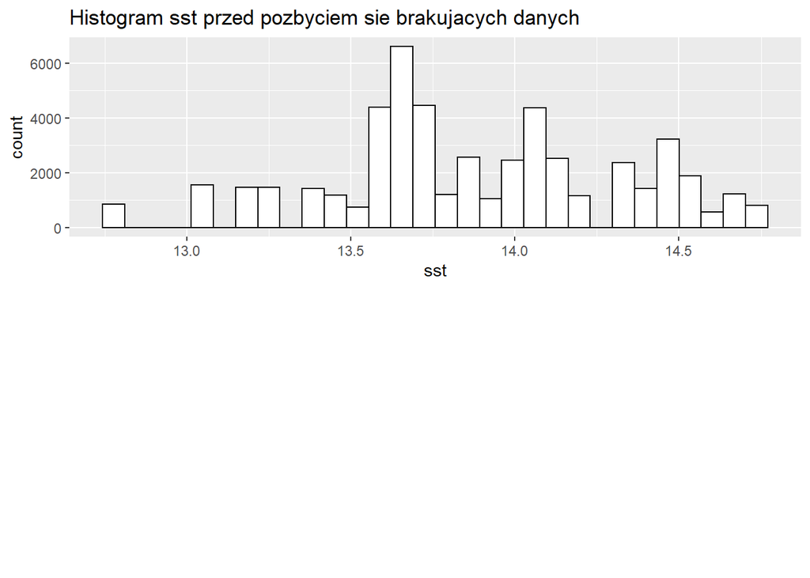

```
##
## attr(,"class")
## [1] "list"      "ggarrange"
```

```r
plot_histograms <- function(data, columns=NULL, ncol=1, nrow=1, createName=function(x) x){
  if(!is.null(columns)){
    columns <- names(data)
  }

  i <- 1
  plots <- list()
  for (column_name in missing_data_columns){
    p <- ggplot(data, aes_string(x = column_name)) +
      geom_histogram(color="black", fill="white") +
      ggtitle(createName(column_name))
    plots[[i]] <- p
    i <- i + 1
  }
  figure <- ggarrange(plotlist = plots, ncol = ncol, nrow = nrow)
  # annotate_figure(figure, top = text_grob("dddDDDD"))
  figure
}



missing_data_columns <- c("cfin1", "cfin2", "chel1", "chel2", "lcop1", "lcop2", "sst")
plot_histograms(data, columns = missing_data_columns, createName = function(x) paste0("Histogram ", x, " przed pozbyciem się brakujących danych"), nrow=2)
```

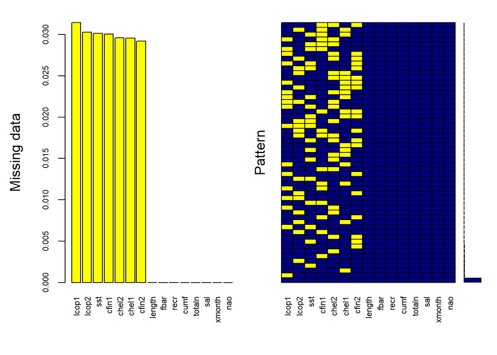

```
##
##  Variables sorted by number of missings:
##  Variable      Count
##     lcop1 0.03143661
##     lcop2 0.03025750
##       sst 0.03012438
##     cfin1 0.03006732
##     chel2 0.02959188
##     chel1 0.02957286
##     cfin2 0.02921152
##    length 0.00000000
##      fbar 0.00000000
##      recr 0.00000000
##      cumf 0.00000000
##    totaln 0.00000000
##       sal 0.00000000
##    xmonth 0.00000000
##       nao 0.00000000
```

```r
mice_plot <- aggr(data, col=c('navyblue','yellow'),
                    numbers=TRUE, sortVars=TRUE,
                    labels=names(data), cex.axis=.7,
                    gap=3, ylab=c("Missing data","Pattern"))
```

```r
completed_data <- data %>%
  mice(m=5,  method = 'cart', seed = 63) %>%
  complete(2)
```

```
## $`1`
```

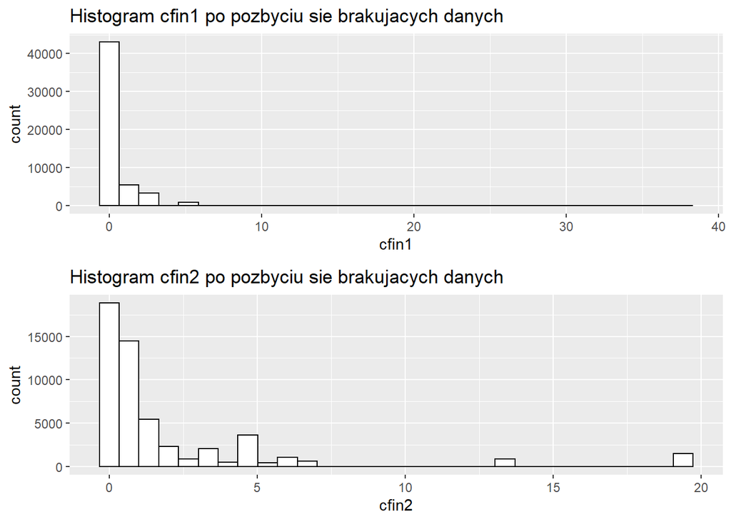

```
##
## $`2`
```

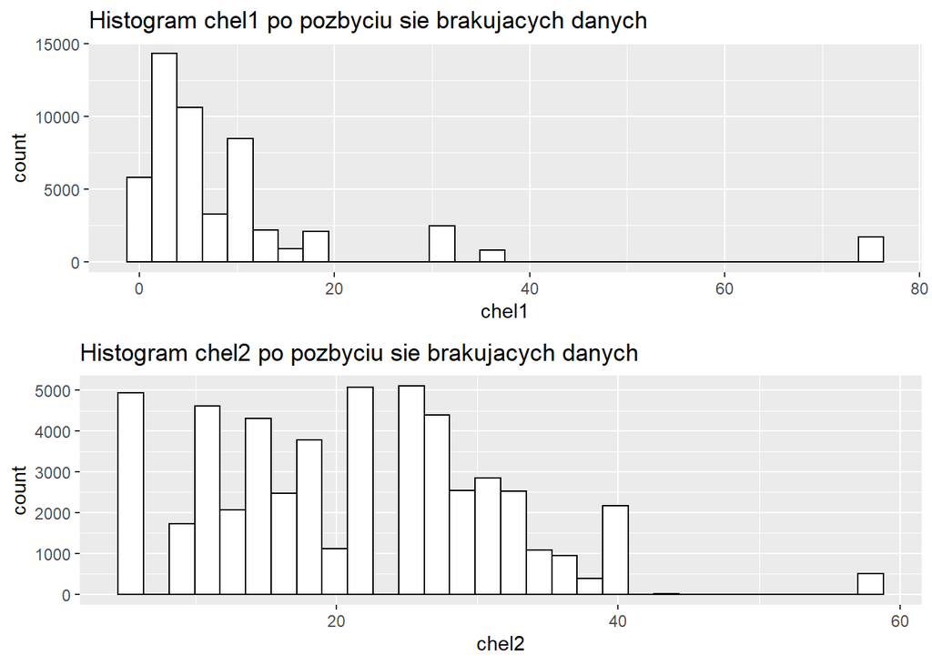

```
##
## $`3`
```

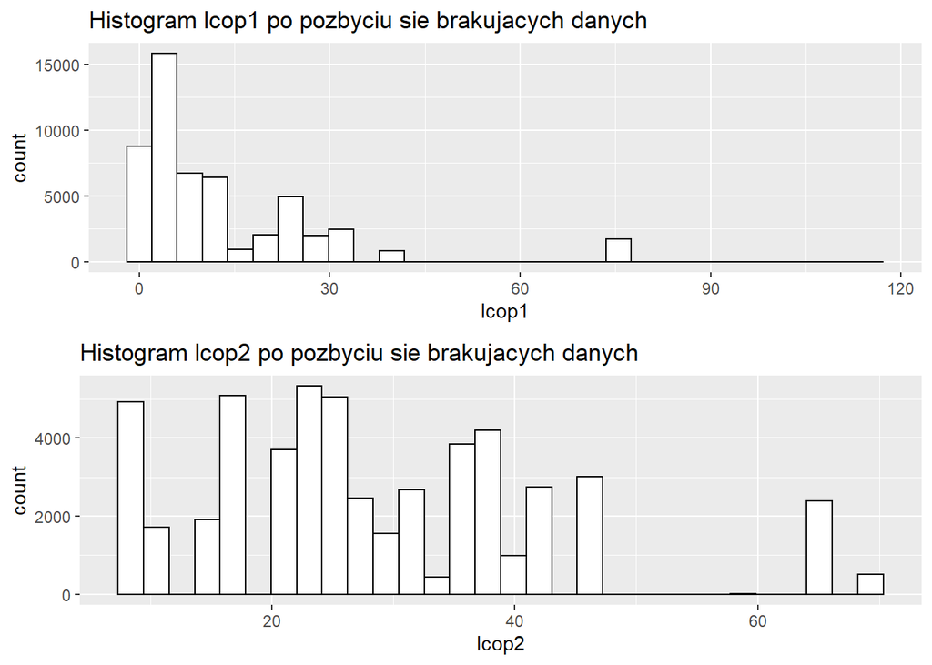

```
##
## $`4`
```

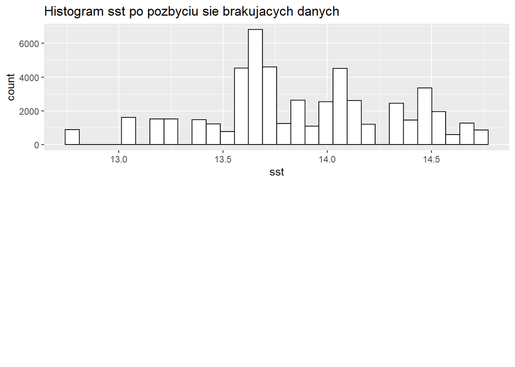

```
##
## attr(,"class")
## [1] "list"      "ggarrange"
```

```r
plot_histograms(completed_data, columns = missing_data_columns, createName = function(x) paste0("Histogram ", x, " po pozbyciu się brakujących danych"), nrow=2)
```

# Wymagania

**Do usunięcia później**

1. Kod wyliczający wykorzystane biblioteki.
2. Kod zapewniający powtarzalność wyników przy każdym uruchomieniu raportu na tych samych danych.
3. Kod pozwalający wczytać dane z pliku.
4. Kod przetwarzający brakujące dane.
5. Sekcję podsumowującą rozmiar zbioru i podstawowe statystyki.
6. Szczegółową analizę wartości atrybutów (np. poprzez prezentację rozkładów wartości).
7. Sekcję sprawdzającą korelacje między zmiennymi; sekcja ta powinna zawierać jakąś formę graficznej prezentacji korelacji.
8. Interaktywny wykres lub animację prezentującą zmianę rozmiaru śledzi w czasie.
9. Sekcję próbującą stworzyć regresor przewidujący rozmiar śledzia (w tej sekcji należy wykorzystać wiedzę z pozostałych punktów oraz wykonać dodatkowe czynności, które mogą poprawić trafność predykcji); dobór parametrów modelu oraz oszacowanie jego skuteczności powinny zostać wykonane za pomocą techniki podziału zbioru na dane uczące, walidujące i testowe; trafność regresji powinna zostać oszacowana na podstawie miar R2 i RMSE.
10. Analizę ważności atrybutów najlepszego znalezionego modelu regresji. Analiza ważności atrybutów powinna stanowić próbę odpowiedzi na pytanie: co sprawia, że rozmiar śledzi zaczął w pewnym momencie maleć.